# 30-Day Mortality Rate of Patients with Pneumonia Admitted to MICU

Ami Sheth

## Introduction

The MIMIC-III (Medical Information Mart for Intensive Care III) is a database containing de-identified health-related data for over 40,000 patients staying in critical care units of Beth Israel Denaconess Medical Center between 2001 and 2012. The database consists of forty different tables pertaining to hospital admissions, patient demographics, patient diagnosis, prescriptions, etc. The following analysis seeks to predict the mortality rate of patients diagnosed with pneumonia who were admitted to the medical intensive care unit (MICU) thirty days after discharge.

## Data Preparation

The MIMIC-III data is accessed by connecting to the PostgreSQL database. A cohort of patients directly admitted into MICU is extracted from the `transfer` table which contains information about the physical location of patients throughout their hospital stay. The `d_icd_diagnoses` table labels all diagnoses according to the Dictionary of International Classification of Diseases, 9th Revision (ICD-9 Codes). From this table, all ICD-9 codes related to pneumonia are stored and matched to patients’ ICD-9 codes in the `diagnoses_icd` table, so that only patients diagnosed with pneumonia remain. Pneumonia may not be listed as the principal diagnosis as explained in [the documentation for the `patients` table](https://mimic.physionet.org/mimictables/diagnoses_icd/). The `seq_num` field is a priority ranking for the diagnoses generated at the end of stay. To focus on patients for whom pneumonia was central to their hospitalization, records with pneumonia in any of the first five diagnosis positions, according to `seq_num`, is kept. The dataset containing only patients from MICU is joined with the dataset containing only pneumonia patients to obtain a cohort restricted to pneumonia patients who were directly admitted into the MICU (`cohort_admissions`)

### CONSORT Flow Diagram

The CONSORT flow diagram summarizes these steps to create the desired cohort:

[figure not shown]

### Code

The following steps are performed to create a cohort of patients who were directly admitted into MICU and were diagnosed with pneumonia.

Load database libraries

```r
library(DBI)
library(RPostgreSQL)
library(tidyverse)
library(lubridate)
```

Connect to PostgreSQL

```r
# Load configuration settings
dbdriver <- "PostgreSQL"
user <- "postgres"
password <- "postgres"
dbname <- "mimic"
schema <- "mimiciii"

# Connect to the database using the configuration settings
con <- dbConnect(RPostgreSQL::PostgreSQL(),
  dbname = dbname,
  user = user,
  password = password
)

# Set the default schema
dbExecute(con, paste("SET search_path TO ", schema, sep = " "))
```

```
## [1] 0
```

```r
con
```

```
## <PostgreSQLConnection>
```

Create a (query) table of patients who were directly admitted into MICU

```r
tbl(con, "transfers") %>%
  select(subject_id, hadm_id, prev_careunit, curr_careunit) %>%
  filter(is.na(prev_careunit) & curr_careunit == "MICU") %>%
  select(subject_id, hadm_id) %>%
  distinct() %>%
  print() -> micu_admissions
```

```
## # Source:   lazy query [?? x 2]
## # Database: postgres 11.0.7 [postgres@/var/run/postgresql:5432/mimic]
##    subject_id hadm_id
##         <int>   <int>
##  1        711  120522
##  2      20863  195453
##  3      97716  178708
##  4      60131  190090
##  5      19705  155006
##  6      11342  165519
##  7      74147  149842
##  8      18958  122966
##  9       7681  175048
## 10      65665  170768
## # … with more rows
```

Restrict to pneumonia patients; to find all possible ICD-9 codes related to pneumonia, search for string `pneumonia` in the `long_title` of table `d_icd_diagnoses`

```r
tbl(con, "d_icd_diagnoses") %>%
  filter(str_detect(tolower(long_title), "pneumonia")) %>%
  print() -> pneu_codes
```

```
## # Source:   lazy query [?? x 4]
## # Database: postgres 11.0.7 [postgres@/var/run/postgresql:5432/mimic]
##    row_id icd9_code short_title       long_title
##     <int> <chr>     <chr>             <chr>
##  1    174 01166     TB pneumonia-oth… Tuberculous pneumonia [any form], tubercl…
##  2    245 00322     Salmonella pneum… Salmonella pneumonia
##  3    168 01160     TB pneumonia-uns… Tuberculous pneumonia [any form], unspeci…
##  4    169 01161     TB pneumonia-no … Tuberculous pneumonia [any form], bacteri…
##  5    170 01162     TB pneumonia-exa… Tuberculous pneumonia [any form], bacteri…
##  6    171 01163     TB pneumonia-mic… Tuberculous pneumonia [any form], tubercl…
##  7    172 01164     TB pneumonia-cul… Tuberculous pneumonia [any form], tubercl…
##  8    173 01165     TB pneumonia-his… Tuberculous pneumonia [any form], tubercl…
##  9    603 0551      Postmeasles pneu… Postmeasles pneumonia
## 10    651 0382      Pneumococcal sep… Pneumococcal septicemia [Streptococcus pn…
## # … with more rows
```

Match the ICD-9 codes related to pneumonia

```r
tbl(con, "diagnoses_icd") %>%
  semi_join(pneu_codes, by = "icd9_code") %>%
  print() -> pneu_admissions
```

```
## # Source:   lazy query [?? x 5]
## # Database: postgres 11.0.7 [postgres@/var/run/postgresql:5432/mimic]
##    row_id subject_id hadm_id seq_num icd9_code
##     <int>      <int>   <int>   <int> <chr>
##  1 318345      28120  120409       2 01164
##  2   3051        250  124271       1 0382
##  3  12412       1068  174792       2 0382
##  4  12601       1085  198028       1 0382
##  5  37477       3370  176021       2 0382
##  6  25929       2322  169179       2 0382
##  7  58698       5242  175154       1 0382
##  8  54397       4883  123172       2 0382
##  9  19561       1754  103405       1 0382
## 10  46483       4140  170984       1 0382
## # … with more rows
```

Include records with pneumonia in any of the first five diagnosis positions, according to the `seq_num` field. `group_by()` to limit the query to the first pneumonia diagnosis for each admission

```r
pneu_admissions %>%
  filter(seq_num <= 5) %>%
  group_by(subject_id, hadm_id) %>%
  filter(min_rank(seq_num) <= 1) %>%
  ungroup() %>%
  select(subject_id, hadm_id, icd9_code, seq_num) %>%
  print() -> pneu_admissions
```

```
## # Source:   lazy query [?? x 4]
## # Database: postgres 11.0.7 [postgres@/var/run/postgresql:5432/mimic]
##    subject_id hadm_id icd9_code seq_num
##         <int>   <int> <chr>       <int>
##  1         31  128652 486             4
##  2         36  165660 486             4
##  3         41  101757 48241           4
##  4         68  108329 486             2
##  5         68  170467 486             2
##  6         85  112077 486             2
##  7         94  140037 486             3
##  8        101  175533 48240           3
##  9        103  130744 486             4
## 10        105  128744 486             2
## # … with more rows
```

`inner_join` the table of admissions to MICU and the table of admissions that include pneumonia diagnosis

```r
micu_admissions %>%
  inner_join(pneu_admissions, by = c("subject_id", "hadm_id")) %>%
  print() -> cohort_admissions
```

```
## # Source:   lazy query [?? x 4]
## # Database: postgres 11.0.7 [postgres@/var/run/postgresql:5432/mimic]
##    subject_id hadm_id icd9_code seq_num
##         <int>   <int> <chr>       <int>
##  1         31  128652 486             4
##  2         36  165660 486             4
##  3         68  108329 486             2
##  4         68  170467 486             2
##  5         85  112077 486             2
##  6         94  140037 486             3
##  7        101  175533 48240           3
##  8        105  128744 486             2
##  9        109  172335 486             2
## 10        111  155897 486             3
## # … with more rows
```

Create a logical variable indicating the pneumonia is the principal diagnosis or not (according to `seq_num`)

```r
cohort_admissions %>%
  mutate(principal_dx = seq_num == 1) %>%
  select(-seq_num) %>%
  print() -> cohort_admissions
```

```
## # Source:   lazy query [?? x 4]
## # Database: postgres 11.0.7 [postgres@/var/run/postgresql:5432/mimic]
##    subject_id hadm_id icd9_code principal_dx
##         <int>   <int> <chr>     <lgl>
##  1         31  128652 486       FALSE
##  2         36  165660 486       FALSE
##  3         68  108329 486       FALSE
##  4         68  170467 486       FALSE
##  5         85  112077 486       FALSE
##  6         94  140037 486       FALSE
##  7        101  175533 48240     FALSE
##  8        105  128744 486       FALSE
##  9        109  172335 486       FALSE
## 10        111  155897 486       FALSE
## # … with more rows
```

Pull the drug severity information from `drgcodes` and right-join it to the query table

```r
tbl(con, "drgcodes") %>%
  filter(str_detect(drg_type, "APR")) %>%
  select(subject_id, hadm_id, drg_severity) %>%
  right_join(cohort_admissions, by = c("subject_id", "hadm_id")) %>%
  mutate(drg_severity = ifelse(is.na(drg_severity), 1, drg_severity)) %>%
  print() -> cohort_admissions
```

```
## # Source:   lazy query [?? x 5]
## # Database: postgres 11.0.7 [postgres@/var/run/postgresql:5432/mimic]
##    subject_id hadm_id drg_severity icd9_code principal_dx
##         <int>   <int>        <dbl> <chr>     <lgl>
##  1         31  128652            1 486       FALSE
##  2         36  165660            3 486       FALSE
##  3         36  165660            3 486       FALSE
##  4         68  108329            4 486       FALSE
##  5         68  170467            4 486       FALSE
##  6         85  112077            3 486       FALSE
##  7         85  112077            3 486       FALSE
##  8         94  140037            2 486       FALSE
##  9        101  175533            1 48240     FALSE
## 10        105  128744            3 486       FALSE
## # … with more rows
```

Pull the admission time `admittime`, discharge time `dischtime`, date of birth `dob`, and date of death `dod`; keep patients who did not die in hospital

```r
cohort_admissions %>%
  left_join(
    select(
      tbl(con, "admissions"),
      subject_id, hadm_id, admittime, dischtime, hospital_expire_flag
    ),
    by = c("subject_id", "hadm_id")
  ) %>%
  filter(hospital_expire_flag == 0) %>% # patients who did not die in hospital
  select(-hospital_expire_flag) %>%
  left_join(
    select(tbl(con, "patients"), subject_id, dob, dod),
    by = "subject_id"
  ) %>%
  print(width = Inf) -> cohort_admissions
```

```
## # Source:   lazy query [?? x 9]
## # Database: postgres 11.0.7 [postgres@/var/run/postgresql:5432/mimic]
##    subject_id hadm_id drg_severity icd9_code principal_dx admittime
##         <int>   <int>        <dbl> <chr>     <lgl>        <dttm>
##  1         36  165660            3 486       FALSE        2134-05-10 11:30:00
##  2         36  165660            3 486       FALSE        2134-05-10 11:30:00
##  3         68  108329            4 486       FALSE        2174-01-04 22:21:00
##  4         68  170467            4 486       FALSE        2173-12-15 16:16:00
##  5         85  112077            3 486       FALSE        2167-07-25 18:49:00
##  6         85  112077            3 486       FALSE        2167-07-25 18:49:00
##  7         94  140037            2 486       FALSE        2176-09-02 14:22:00
##  8        105  128744            3 486       FALSE        2189-02-21 01:45:00
##  9        109  172335            4 486       FALSE        2141-09-18 10:32:00
## 10        109  172335            4 486       FALSE        2141-09-18 10:32:00
##    dischtime           dob                 dod
##    <dttm>              <dttm>              <dttm>
##  1 2134-05-20 13:16:00 2061-08-17 00:00:00 NA
##  2 2134-05-20 13:16:00 2061-08-17 00:00:00 NA
##  3 2174-01-19 11:30:00 2132-02-29 00:00:00 2174-02-11 00:00:00
##  4 2174-01-03 18:30:00 2132-02-29 00:00:00 2174-02-11 00:00:00
##  5 2167-07-30 15:24:00 2090-09-18 00:00:00 2167-09-12 00:00:00
##  6 2167-07-30 15:24:00 2090-09-18 00:00:00 2167-09-12 00:00:00
##  7 2176-09-25 13:15:00 2101-09-20 00:00:00 2178-08-17 00:00:00
##  8 2189-02-25 10:05:00 2153-09-26 00:00:00 2190-02-15 00:00:00
##  9 2141-09-24 13:53:00 2117-08-07 00:00:00 2142-08-30 00:00:00
## 10 2141-09-24 13:53:00 2117-08-07 00:00:00 2142-08-30 00:00:00
## # … with more rows
```

Add `age` (at admission) variable into the table; remove patients older than 90 yrs from the analysis

```r
cohort_admissions %>%
  mutate(tt_death = DATE_PART("day", dod - dischtime)) %>%
  mutate(mortality = tt_death <= 30) %>%
  mutate(age = date_part("year", admittime) - date_part("year", dob)) %>%
  filter(age < 90) %>%
  mutate(age = age - ifelse(
    date_part("month", admittime) < date_part("month", dob) |
      (
        date_part("month", admittime) == date_part("month", dob) &
          date_part("day", admittime) < date_part("day", dob)
      ),
    1,
    0
  )) %>%
  select(-admittime, -dischtime, -dob, -dod, -tt_death) %>%
  select(subject_id, hadm_id, age, mortality, everything()) %>%
  print() -> cohort_admissions
```

```
## # Source:   lazy query [?? x 7]
## # Database: postgres 11.0.7 [postgres@/var/run/postgresql:5432/mimic]
##    subject_id hadm_id   age mortality drg_severity icd9_code principal_dx
##         <int>   <int> <dbl> <lgl>            <dbl> <chr>     <lgl>
##  1         36  165660    72 NA                   3 486       FALSE
##  2         36  165660    72 NA                   3 486       FALSE
##  3         68  108329    41 TRUE                 4 486       FALSE
##  4         68  170467    41 FALSE                4 486       FALSE
##  5         85  112077    76 FALSE                3 486       FALSE
##  6         85  112077    76 FALSE                3 486       FALSE
##  7         94  140037    74 FALSE                2 486       FALSE
##  8        105  128744    35 FALSE                3 486       FALSE
##  9        109  172335    24 FALSE                4 486       FALSE
## 10        109  172335    24 FALSE                4 486       FALSE
## # … with more rows
```

Merge some demographic information (ethnicity, gender) into `cohort_admissions`

```r
tbl(con, "admissions") %>%
  select(subject_id, ethnicity) %>%
  distinct() %>%
  print() -> cohort_subjects
```

```
## # Source:   lazy query [?? x 2]
## # Database: postgres 11.0.7 [postgres@/var/run/postgresql:5432/mimic]
##    subject_id ethnicity
##         <int> <chr>
##  1       1421 BLACK/AFRICAN AMERICAN
##  2      68255 ASIAN
##  3       4901 WHITE
##  4      81232 WHITE
##  5      28292 WHITE
##  6      21741 WHITE
##  7      12175 BLACK/AFRICAN AMERICAN
##  8        341 BLACK/AFRICAN AMERICAN
##  9      48629 UNABLE TO OBTAIN
## 10      18688 HISPANIC OR LATINO
## # … with more rows
```

```r
tbl(con, "patients") %>%
  select(subject_id, gender) %>%
  distinct() %>%
  full_join(cohort_subjects, by = "subject_id") %>%
  print() -> cohort_subjects
```

```
## # Source:   lazy query [?? x 3]
## # Database: postgres 11.0.7 [postgres@/var/run/postgresql:5432/mimic]
##    subject_id gender ethnicity
##         <int> <chr>  <chr>
##  1      26121 M      WHITE
##  2       7489 F      WHITE
##  3      81661 M      WHITE
##  4      30273 F      WHITE
##  5      55935 F      BLACK/AFRICAN AMERICAN
##  6      63914 M      UNABLE TO OBTAIN
##  7      19393 M      WHITE
##  8      15861 M      WHITE
##  9      12289 F      WHITE
## 10      31927 F      PORTUGUESE
## # … with more rows
```

```r
cohort_subjects %>%
  semi_join(cohort_admissions, by = "subject_id") %>%
  print() -> cohort_subjects
```

```
## # Source:   lazy query [?? x 3]
## # Database: postgres 11.0.7 [postgres@/var/run/postgresql:5432/mimic]
##    subject_id gender ethnicity
##         <int> <chr>  <chr>
##  1      30273 F      WHITE
##  2      15861 M      WHITE
##  3      82100 M      WHITE
##  4      21037 F      WHITE
##  5      54805 M      OTHER
##  6      99185 M      WHITE
##  7        124 M      WHITE
##  8      85828 M      BLACK/AFRICAN AMERICAN
##  9      63519 M      WHITE
## 10      24047 M      WHITE
## # … with more rows
```

Resolve some diversity and inconsistency in the `ethnicity` field

```r
unknown_ethnicity <- c(
  "OTHER",
  "UNABLE TO OBTAIN",
  "UNKNOWN/NOT SPECIFIED",
  "MULTI RACE ETHNICITY",
  "PATIENT DECLINED TO ANSWER",
  "UNKNOWN"
)

cohort_subjects %>%
  collect() %>%
  mutate(ethnic_group = case_when(
    str_detect(ethnicity, "^ASIAN") ~ "ASIAN",
    str_detect(ethnicity, "^BLACK") ~ "BLACK",
    str_detect(ethnicity, "^HISPANIC") ~ "HISPANIC",
    str_detect(ethnicity, "^WHITE") ~ "WHITE",
    ethnicity %in% unknown_ethnicity ~ NA_character_,
    TRUE ~ NA_character_
  )) %>%
  select(subject_id, gender, ethnic_group) %>%
  print() -> cohort_subjects
```

```
## # A tibble: 2,498 x 3
##    subject_id gender ethnic_group
##         <int> <chr>  <chr>
##  1         36 M      WHITE
##  2         68 F      BLACK
##  3         85 M      WHITE
##  4         94 M      ASIAN
##  5        105 F      BLACK
##  6        109 F      BLACK
##  7        124 M      WHITE
##  8        184 M      WHITE
##  9        203 M      ASIAN
## 10        211 F      WHITE
## # … with 2,488 more rows
```

Some patients are coded as belonging to more than one ethnic group. To resolve these inconsistencies, define a helper function to pick the modal value from a vector of values in R, which can be used by the `summarize()` function to choose one ethnic group for each patient

```r
most <- function(x) {
  if (all(is.na(x))) {
    return(NA_character_)
  }
  y <- table(x, useNA = "no")
  if (length(which(y == max(y))) > 1) {
    return(NA_character_)
  }
  return(names(y)[which.max(y)])
}

cohort_subjects %>%
  group_by(subject_id) %>%
  summarize(ethnic_group = most(ethnic_group)) %>%
  ungroup() %>%
  mutate(ethnic_group = ifelse(is.na(ethnic_group), "UNKNOWN",
    ethnic_group
  )) %>%
  print() -> cohort_ethnic_groups
```

```
## # A tibble: 2,460 x 2
##    subject_id ethnic_group
##         <int> <chr>
##  1         36 WHITE
##  2         68 BLACK
##  3         85 WHITE
##  4         94 ASIAN
##  5        105 BLACK
##  6        109 BLACK
##  7        124 WHITE
##  8        184 WHITE
##  9        203 ASIAN
## 10        211 WHITE
## # … with 2,450 more rows
```

```r
cohort_subjects %>%
  select(subject_id, gender) %>%
  left_join(cohort_ethnic_groups, by = "subject_id") %>%
  print() -> cohort_subjects
```

```
## # A tibble: 2,498 x 3
##    subject_id gender ethnic_group
##         <int> <chr>  <chr>
##  1         36 M      WHITE
##  2         68 F      BLACK
##  3         85 M      WHITE
##  4         94 M      ASIAN
##  5        105 F      BLACK
##  6        109 F      BLACK
##  7        124 M      WHITE
##  8        184 M      WHITE
##  9        203 M      ASIAN
## 10        211 F      WHITE
## # … with 2,488 more rows
```

Add the demographic information `gender` and `ethnicity` into `cohort_admissions` table

```r
cohort_admissions %>%
  left_join(cohort_subjects, by = "subject_id", copy = TRUE) %>%
  print() -> cohort_admissions
```

```
## # Source:   lazy query [?? x 9]
## # Database: postgres 11.0.7 [postgres@/var/run/postgresql:5432/mimic]
##    subject_id hadm_id   age mortality drg_severity icd9_code principal_dx gender
##         <int>   <int> <dbl> <lgl>            <dbl> <chr>     <lgl>        <chr>
##  1         36  165660    72 NA                   3 486       FALSE        M
##  2         36  165660    72 NA                   3 486       FALSE        M
##  3         68  108329    41 TRUE                 4 486       FALSE        F
##  4         68  170467    41 FALSE                4 486       FALSE        F
##  5         85  112077    76 FALSE                3 486       FALSE        M
##  6         85  112077    76 FALSE                3 486       FALSE        M
##  7         94  140037    74 FALSE                2 486       FALSE        M
##  8        105  128744    35 FALSE                3 486       FALSE        F
##  9        109  172335    24 FALSE                4 486       FALSE        F
## 10        109  172335    24 FALSE                4 486       FALSE        F
## # … with more rows, and 1 more variable: ethnic_group <chr>
```

```r
final_cohort <- collect(cohort_admissions)
```

Close the connection to database

```r
dbDisconnect(con)
```

```
## [1] TRUE
```

## Data Visualization

### Plots for Demographic Features

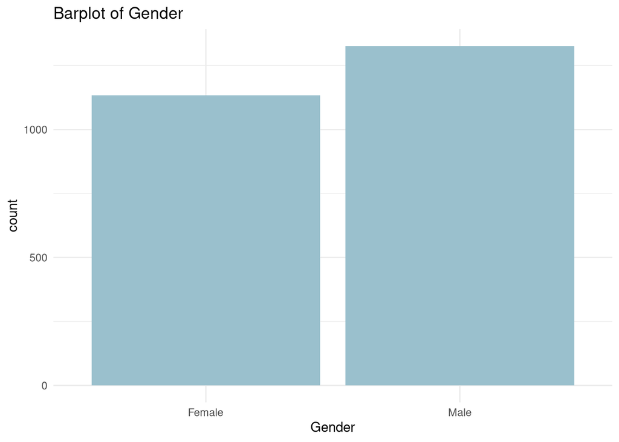

```r
# Gender
final_cohort %>%
  distinct(subject_id, .keep_all = TRUE) %>%
  ggplot(aes(x = gender)) +
  geom_bar(fill = "lightblue3") +
  scale_x_discrete(labels = c("Female", "Male")) +
  labs(title = "Barplot of Gender", x = "Gender") +
  theme_minimal()
```

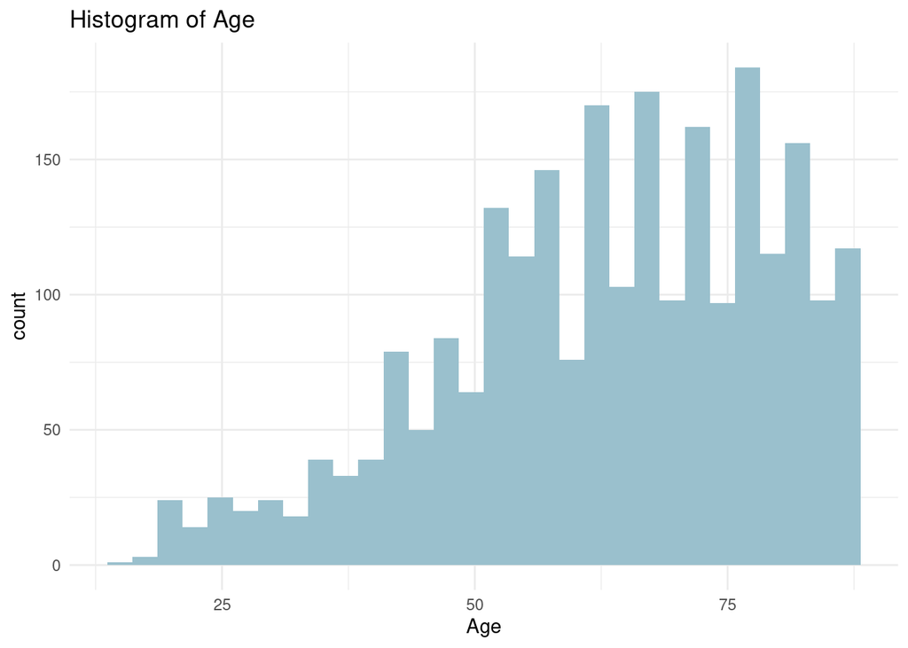

```r
# Age
final_cohort %>%
  distinct(subject_id, .keep_all = TRUE) %>%
  ggplot(aes(x = age)) +
  geom_histogram(bins = 30, fill = "lightblue3") +
  labs(title = "Histogram of Age", x = "Age") +
  theme_minimal()
```

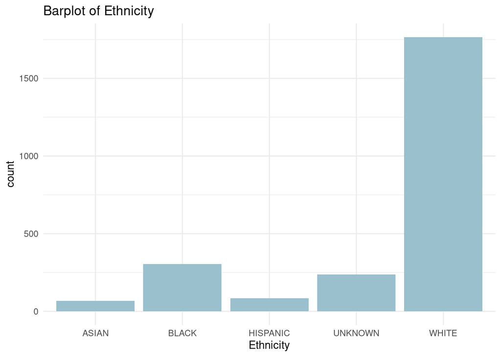

```r
# Ethnic Group
final_cohort %>%
  distinct(subject_id, .keep_all = TRUE) %>%
  ggplot(aes(x = ethnic_group)) +
  geom_bar(fill = "lightblue3") +
  labs(title = "Barplot of Ethnicity", x = "Ethnicity") +
  theme_minimal()
```

### Plots for Patients Relationship to Pneumonia

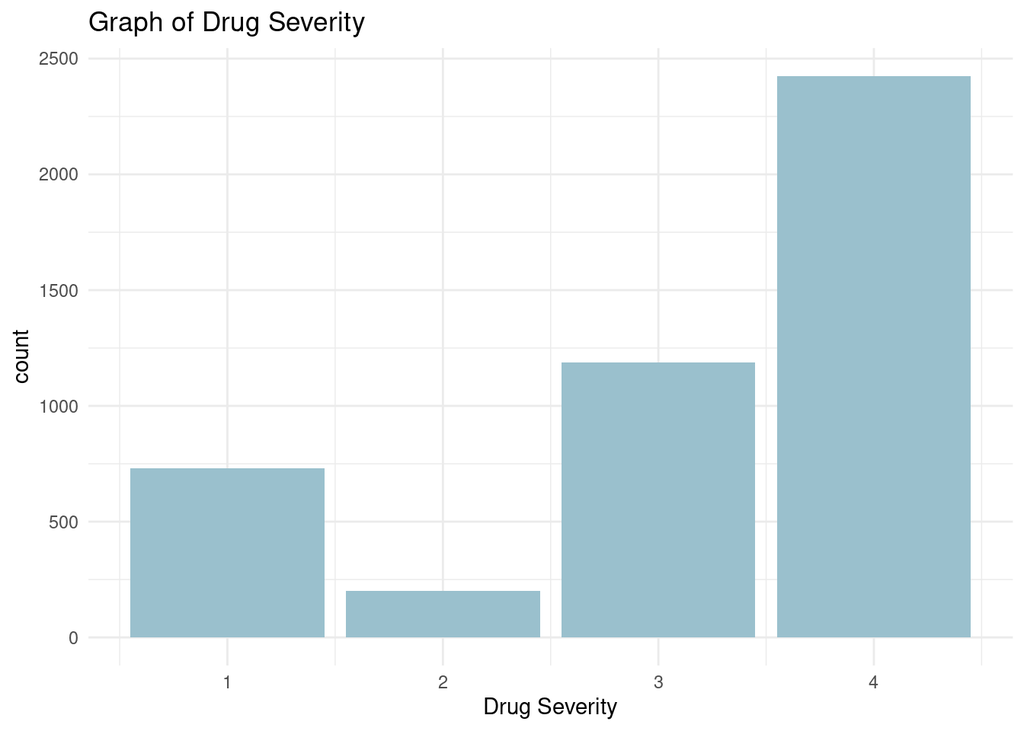

```r
# Drug Severity
final_cohort %>%
  ggplot(aes(x = drg_severity)) +
  geom_bar(fill = "lightblue3") +
  labs(title = "Graph of Drug Severity", x = "Drug Severity") +
  theme_minimal()
```

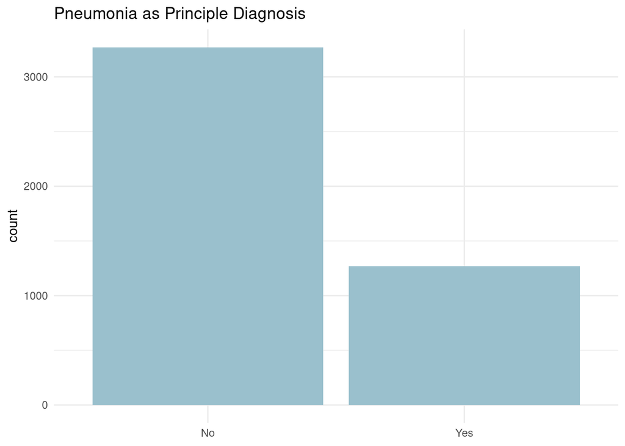

```r
# Principle Disease
final_cohort %>%
  ggplot(aes(x = principal_dx)) +
  geom_bar(fill = "lightblue3") +
  scale_x_discrete(labels = c("No", "Yes")) +
  labs(title = "Pneumonia as Principle Diagnosis", x = NULL) +
  theme_minimal()
```

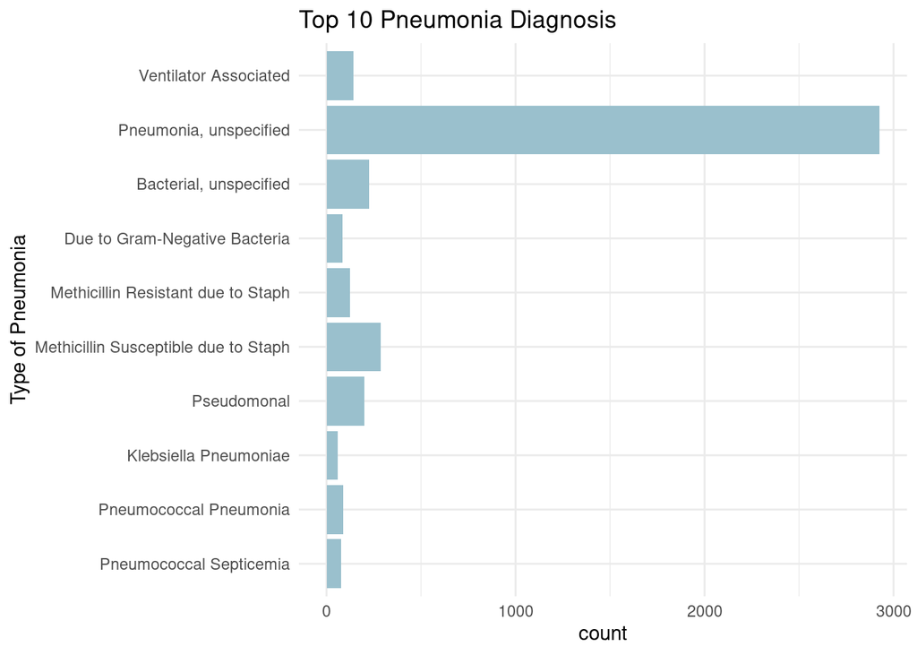

```r
# ICDA_Code
final_cohort %>%
  count(icd9_code) %>%
  arrange(desc(n)) %>%
  head(n = 10) %>%
  ggplot(aes(x = icd9_code, y = n)) +
  geom_bar(stat = "identity", fill = "lightblue3") +
  coord_flip() +
  scale_x_discrete(labels = c(
    "Pneumococcal Septicemia",
    "Pneumococcal Pneumonia",
    "Klebsiella Pneumoniae",
    "Pseudomonal",
    "Methicillin Susceptible due to Staph",
    "Methicillin Resistant due to Staph",
    "Due to Gram-Negative Bacteria",
    "Bacterial, unspecified",
    "Pneumonia, unspecified",
    "Ventilator Associated"
  )) +
  labs(
    title = "Top 10 Pneumonia Diagnosis", x = "Type of Pneumonia",
    y = "count"
  ) +
  theme_minimal()
```

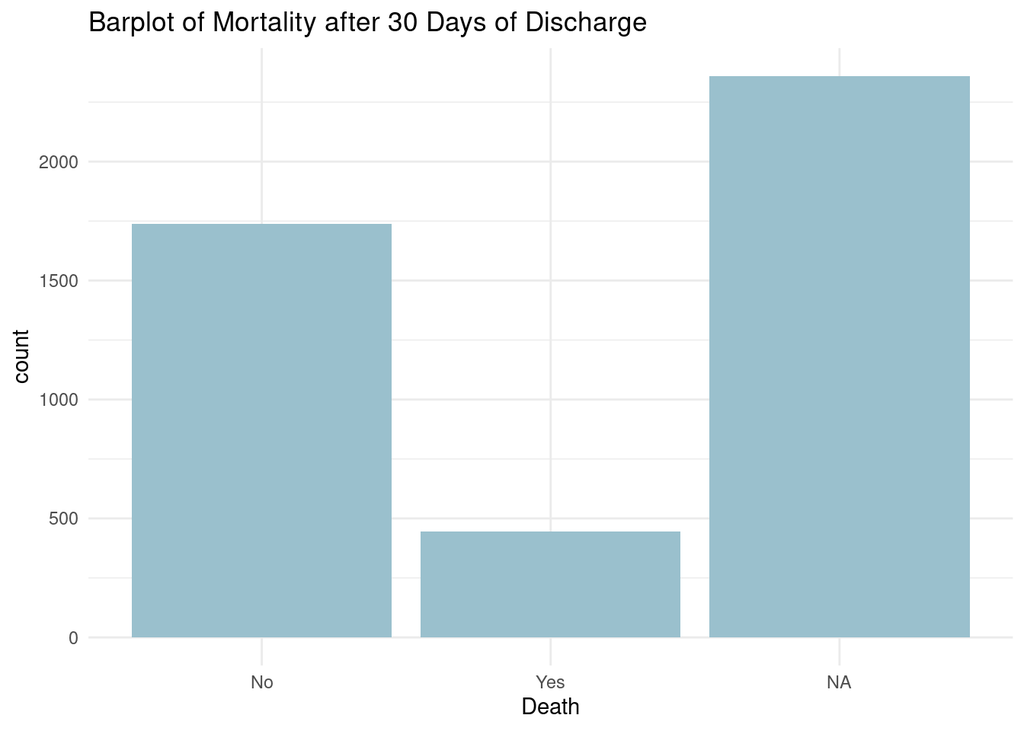

```r
# Mortality
final_cohort %>%
  ggplot(aes(x = mortality)) +
  geom_bar(fill = "lightblue3") +
  scale_x_discrete(labels = c("No", "Yes", "NA")) +
  labs(
    title = "Barplot of Mortality after 30 Days of Discharge",
    x = "Death"
  ) +
  theme_minimal()
```

## Analysis

### 1. Logistic Regression

Before running a logistic regression, the ICD-9 Codes are re-coded as an indicator variable with 1 representing if the patients’ ICD-9 code is in the top five most common types of pneumonia. Additionally, all character variables are converted into factors. The `cohort_admissions` data is split into a training and test set with 75% of the observations in the training set. A logistic regression is performed on the training set with age, drug severity, ICD-9 code, principal drug, gender, and ethnic group as the covariates. A root mean squared error (RMSE) is calculated to measure performance.

```r
final_cohort1 <- final_cohort

# Recode icd9_code
top_5 <- c("486", "48241", "4829", "4821", "99731")
final_cohort1$icd9_code <- ifelse(final_cohort1$icd9_code %in% top_5,
  TRUE, FALSE
)

# 75% of the sample size
smp_size <- floor(0.75 * nrow(final_cohort))

# Make all character variables into factors
columns <- c("drg_severity", "gender", "ethnic_group")

final_cohort1[, columns] <- lapply(final_cohort1[, columns], as.factor)

# Set the seed to make partition reproducible
set.seed(12345)

# Create a training and testing set
train_ind <- sample(seq_len(nrow(final_cohort1)), size = smp_size)
train <- final_cohort1[train_ind, ]
test <- final_cohort1[-train_ind, ]

# Build the logistic regression model
logit <- glm(mortality ~ age + drg_severity + icd9_code + principal_dx +
  gender + ethnic_group, data = train, family = binomial)

summary(logit)
```

```
##
## Call:
## glm(formula = mortality ~ age + drg_severity + icd9_code + principal_dx +
##     gender + ethnic_group, family = binomial, data = train)
##
## Deviance Residuals:
##     Min       1Q   Median       3Q      Max
## -1.0275  -0.7185  -0.6183  -0.4720   2.2641
##
## Coefficients:
##                       Estimate Std. Error z value Pr(>|z|)
## (Intercept)          -2.723631   0.559937  -4.864 1.15e-06 ***
## age                   0.017671   0.004812   3.673 0.000240 ***
## drg_severity2         0.548156   0.458040   1.197 0.231406
## drg_severity3         0.259765   0.202112   1.285 0.198703
## drg_severity4         0.594100   0.174722   3.400 0.000673 ***
## icd9_codeTRUE         0.166709   0.182106   0.915 0.359957
## principal_dxTRUE     -0.288277   0.149787  -1.925 0.054282 .
## genderM               0.061041   0.127016   0.481 0.630816
## ethnic_groupBLACK    -0.635278   0.424734  -1.496 0.134730
## ethnic_groupHISPANIC -0.567465   0.529390  -1.072 0.283755
## ethnic_groupUNKNOWN   0.097476   0.446084   0.219 0.827028
## ethnic_groupWHITE    -0.361481   0.382526  -0.945 0.344668
## ---
## Signif. codes:  0 '***' 0.001 '**' 0.01 '*' 0.05 '.' 0.1 ' ' 1
##
## (Dispersion parameter for binomial family taken to be 1)
##
##     Null deviance: 1662.8  on 1644  degrees of freedom
## Residual deviance: 1621.6  on 1633  degrees of freedom
##   (1761 observations deleted due to missingness)
## AIC: 1645.6
##
## Number of Fisher Scoring iterations: 4
```

```r
# Predict mortality on the test set
mortality_hat <- predict(logit, test, type = "response")

# Calculate RMSE
sq_diff <- (test$mortality - mortality_hat)^2
root_mse <- sqrt(mean(sq_diff, na.rm = TRUE))
paste("Root MSE:", round(root_mse, 4), sep = " ")
```

```
## [1] "Root MSE: 0.3956"
```

### 2. Neural Network

Before running a neural network, all categorical variables are converted to dummy variables, and `subject_id` and `hadm_id` are removed from the model since they are unique to each patient and have no association to mortality rate. Additionally, the neural network cannot be performed on variables with missing data, so all observations containing a missing value are removed from the dataset. This reduces the data to 2,183 patients. The data is further split up into a training and test set with 1,637 and 546 patients respectively. The neural network is performed on the training set and predicted on the test set. A RMSE is calculated to measure performance.

```r
# Install Neural Network Package if necessary
if ("neuralnet" %in% rownames(installed.packages()) == FALSE) {
  install.packages("neuralnet")
}
library(neuralnet)
```

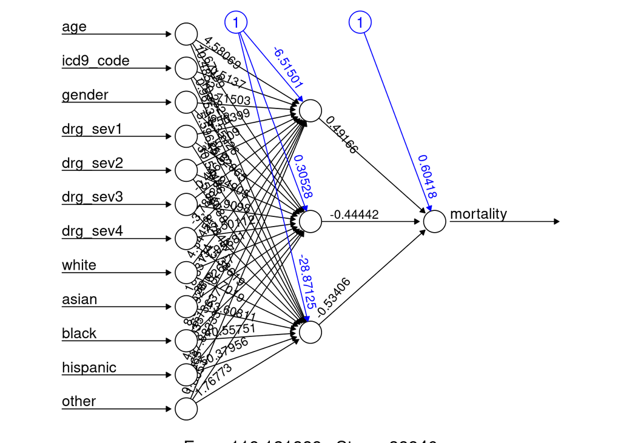

```r
# Convert all categorical variables to dummy variables
final_cohort2 <- final_cohort1 %>%
  mutate(
    mortality = ifelse(mortality == TRUE, 1, 0),
    principal_dx = ifelse(principal_dx == TRUE, 1, 0),
    icd9_code = ifelse(icd9_code == TRUE, 1, 0),
    gender = ifelse(gender == "M", 1, 0),
    drg_sev1 = ifelse(drg_severity == 1, 1, 0),
    drg_sev2 = ifelse(drg_severity == 2, 1, 0),
    drg_sev3 = ifelse(drg_severity == 3, 1, 0),
    drg_sev4 = ifelse(drg_severity == 4, 1, 0),
    white = ifelse(ethnic_group == "WHITE", 1, 0),
    asian = ifelse(ethnic_group == "ASIAN", 1, 0),
    black = ifelse(ethnic_group == "BLACK", 1, 0),
    hispanic = ifelse(ethnic_group == "HISPANIC", 1, 0),
    other = ifelse(ethnic_group == "OTHER", 1, 0),
    age = scale(age)
  ) %>%
  select(-c("subject_id", "hadm_id", "drg_severity", "ethnic_group")) %>%
  select("mortality", everything())

# Remove NA's from mortality and create training set
final_tt <- na.omit(final_cohort2)
tt_size <- floor(0.75 * nrow(final_tt))
tt_ind <- sample(seq_len(nrow(final_tt)), size = tt_size)

ttrain <- final_tt[tt_ind, ]
x_train <- ttrain %>% select(-mortality)

# Create testing set
ttest <- final_tt[-tt_ind, ]
x_test <- ttest %>% select(-mortality)

# Run the Neural Network
set.seed(12345)
NN <- neuralnet(mortality ~ age + icd9_code + gender + drg_sev1 + drg_sev2 +
  drg_sev3 + drg_sev4 + white + asian + black + hispanic + other,
ttrain,
hidden = 3, linear.output = T
)

# Plot neural network
plot(NN, rep = "best")
```

```r
# Prediction
predict_testNN <- compute(NN, x_test)
predict_testNN <- (predict_testNN$net.result *
  (max(final_tt$mortality) - min(final_tt$mortality))) +
  min(final_tt$mortality)

# Calculate RMSE
RMSE.NN <- (sum((ttest$mortality - predict_testNN)^2) / nrow(ttest))^0.5
paste("Root MSE:", round(RMSE.NN, 4), sep = " ")
```

```
## [1] "Root MSE: 0.4103"
```